# Group Project 3

Biology 368/664 Bucknell University

Prof. Ken Field

9 Feb 2022

#### Project Outline

Data set we are using: https://data.cdc.gov/NCHS/Provisional-COVID-19-Deaths-by-Sex-and-Age/9bhg-hcku/data

Outline: 1) Introduction to class 2) Introduction to R (M - Done) Define RMD vs Regular R Loading Data Set Load Packages Refer to glossary for a function/stats overview… 3) Explore Data Set (with function explanations) (A) Formulate a question Read data Check packaging Run structure Look at top and bottom of data Check your n’s 4) Visualize Data Set Timeline vs death (M) ***** Rank net deaths by state (B - Coding Done) West coast vs east coast (A) Male female histogram with death (A) Do older people have higher death rates than younger (B) 5) Statistical analysis (linear model?) to answer hypothesis Age groups and death Linear Model (B) Coast and Death (A) 6) Glossary of Functions and statistical analyses (A+B+M)

#### Project Content

#INTRODUCTION TO EPIDEMIOLOGY:

Epidemiology is the “study of distribution and determinants of health related states among specified populations and the application of that study to control health problems” (A Dictionary of Epidemiology). The purpose of epidemiology in public health practice is to: (1) discover and analyze agents that affect heath, (2) determining causes of illness, disability, and death, (3) identification of populations at risk, and (4) develop effective programs and services to to improve population health. Many epidemiologists solve health problems through a formal scientific approach that includes data collection, assessment, hypothesis testing, and action.

The employment of epidemiology has been notably publicized by the COVID-19 epidemic. As many people have been impacted by the virus in various capacities, this has sparked curiosity into how professionals identify, measure, and represent the epidemiology of such infections. In this R tutorial, we will assume the role of an epidemiologist and conduct a formal scientific method using a COVID-19 dataset provided by the CDC.

At the conclusion of this project, the following should be accomplished: 1. Relate epidemiology data collection to data science/analysis 2. Carry out the scientific method a. Perform an exploration of the dataset using R b. Perform basic data analysis using R c. Draw conclusions from the analysis

First it is important to understand the different types of files you can use in RStudio. Today we will go over R Markdown and R Notebook

R Markdown files allow you to include text with embedded R code chunks. When the document is knitted and finalized you will be able to see the text, code chunks, and the output of those embedded chunks. This is a great tool for authors because it saves the time of copy and pasting graphs or tables into a report and aids in reproducibility. Using R Markdown allows others to see exactly what was done to produce the figures.

R Notebook is quite similar to R Markdown except in a notebook only one line is sent at a time. In contrast R Markdown executes the entire code chunk at once. Another large difference is when a R Notebook file is rendered no code is re-run, only the code that has already been run will be presented in produced document. Whereas when an R Markdown file is rendered all code chunks are re-run and it will not allow you to convert it to a document if there is an error in a code chunk.

##Lets talk about a few of the basics to get you set up to use R.

To create headers in the text, you place a single hash tag (#) in front of the text. For subheaders, use 2 hash tags (##).

If you want your text to be italicized, surround the text with asterisk (*). In order for the text to be bolded surround it with two asterisks (**) To create a list place on asterisk (*) in front of each line.

### ^These effects only work after rendering/knitting, right? We might want to explain knitting before this and say they arent implimented until the markdown is knit so they hypothetically wouldnt be confused when they didnt see any bold/italics popup right away (BT comment)

Rendering is when you transform the markdown file into a HTML, PDF, or word document and this can be done by clicking on the knit button. When you press knit it will run all of your code and create an output. If you want to omit the code but include the results of a chunk in your final document use echo = FALSE. If you want to omit the code and the results form the document use include = FALSE, like I have done below.

This code helps set up the R markdown document to make a nice clean html file for sharing. Click the green triangle to run the code chunk.

###potentially add a comment explaining what a chunk is? (BT comment)

Packages are collections of R functions, data, and compiled code which are stored in the library. The require function is used to ensure we actually get the package we want and if R is unable to receive it, the code will come back with an error or FALSE.

Note that all of your packages should be installed in the first code chunk. If you are coding and realize you need another package you should go back up to your first chunk and add it in.

Normally the R setup chunk can be included in the load libraries chunk, but I separated them today to allow for proper explanation.

You should always load tidyverse library, which includes *dplyr*, *ggplot2*, *readr*, and other packages.

Tidyverse should generally be the last package installed.

Now we will load in the data set that we will be using today.

###Consistency with dataset vs data set lingo? (BT comment)

Here we will walk through how to load your data set in and what each part of the code means * First on the left you put the name you want for your data set. * < - This assigns the data frame to a variable * read_csv reads the data into RStudio as a data frame * within the parentheses is how you tell it where to find your data * the period (.) indicates that the data is located one folder or click away from your RMD file

Click this green arrow to run a chunk of code that produces output. If this code is successful, you should see “Covid_19” appear as a dataframe in the top right box of the RStudio interface under the “Environment” tab.

```r
Covid_19 <- read_csv("./Data/Provisional_COVID-19_Deaths_by_Sex_and_Age.csv")
```

Click on your dataset in the Environment tab and it will pull up a tab for you to view it. Before you start exploring your data set you should check to see if any column names have spaces in them. Rstudio does not like spaces, thus, it is just easier to rename the columns.

In the code chunk below we are changing all of the spaces in the column names to periods (.). This will make the data much easier to work with. After running the code chunk, check your dataframe to see that the change was successful.

```r
# Below is a very handy way to eliminate those annoying spaces in the column names!
names(Covid_19) <- make.names(names(Covid_19))
```

EXPLORATION OF DATASET:

When a dataset is uploaded, there is an informal checklist to complete before visualization and analysis. One should become familiar with the elements in the dataset. The dataframe provides epidemiological data that is inclusive of: 1.Data “as of” date 2.Start dates of data collection 3.End dates of data collection 4.Grouped data by month, year, or total 5.Year of collected data (if applicable) 6.Month of data collection (if applicable) 7.State of data collection, or the entire United States 8.Sex divided into male, female, or total 9.Varied age groups or total collections 10.COVID-19 Deaths 11.Total Deaths 12.Pneumonia Deaths 13.Pneumonia Deaths and COVID-19 Deaths 14.Influenza Deaths 15.Pneumonia, Influenza, or COVID-19 Deaths 16.Footnotes

These variables are all divided into their own column. Just by initially looking through these variables, one can notice some complexities that should be noted. This dataframe includes both summed total data and individual unit data. Thus, both broad and narrow analysis can be made using the dataset. For example, could could compare total deaths in the United States by age group, or one could look at total deaths by month, sex, and age group in a particular state. Caution should be used, however, when filtering the data when conducting an analysis to answer a particular question. Finally, for this dataframe, there are 82620 observations that can be inferred as individual points of collection.

##Formulating a Question:

Once the variables of the dataframe have been assessed, one should formulate a question. Assuming this dataframe was given to an epidemiologist, they may be particularity interested in the time, state, sex, and COVID-19 Death variables. Formulating a question at the beginning of data analysis can limit extraneous paths taken with a large dataset. A precise question and/or hypothesis can eliminate unnecessary variables from the subsequential analysis.

======= Questions we are interested in for this R tutorial: 1. Do males or females have more COVID-19 deaths per month? (Pennsylvania data) 2. Does west or east coast have more COVID-19 deaths? 3. Do older people have higher COVID-19 deaths?

The hypothesis(s) we are interested in for this R tutorial are: 1. We hypothesize that there will be no difference in COVID-19 deaths between the to genders. 2. We hypothesize that there will be more COVID-19 deaths reported for the East coast. 3. We hypothesize that there will be more COVID-19 deaths reported for older individuals.

##Read Data:

The next step in exploratory data analysis is to read in a portion of data. The purpose of this task is to determine if the data is messy and should be cleaned. Messy data will often times not be orderly, have missing values, and is not suitable for immediate data visualization. As the data provided was from the CDC, we can expect relatively “clean” data.

```r
library(readr)
#Covid_19 <- read_csv("./Data/Provisional_COVID-19_Deaths_by_Sex_and_Age.csv")
summary(Covid_19)
```

```
  Data.As.Of         Start.Date          End.Date            Group                Year          Month
 Length:82620       Length:82620       Length:82620       Length:82620       Min.   :2020   Min.   : 1.000
 Class :character   Class :character   Class :character   Class :character   1st Qu.:2020   1st Qu.: 3.000
 Mode  :character   Mode  :character   Mode  :character   Mode  :character   Median :2021   Median : 6.000
                                                                             Mean   :2021   Mean   : 6.115
                                                                             3rd Qu.:2021   3rd Qu.: 9.000
                                                                             Max.   :2022   Max.   :12.000
                                                                             NA's   :2754   NA's   :11016
    State               Sex             Age.Group         COVID.19.Deaths     Total.Deaths
 Length:82620       Length:82620       Length:82620       Min.   :     0.0   Min.   :      0
 Class :character   Class :character   Class :character   1st Qu.:     0.0   1st Qu.:     39
 Mode  :character   Mode  :character   Mode  :character   Median :    11.0   Median :    147
                                                          Mean   :   391.7   Mean   :   2741
                                                          3rd Qu.:    72.0   3rd Qu.:    660
                                                          Max.   :898699.0   Max.   :7070005
                                                          NA's   :20551      NA's   :12132
 Pneumonia.Deaths   Pneumonia.and.COVID.19.Deaths Influenza.Deaths    Pneumonia..Influenza..or.COVID.19.Deaths
 Min.   :     0.0   Min.   :     0.0              Min.   :    0.000   Min.   :      0.0
 1st Qu.:     0.0   1st Qu.:     0.0              1st Qu.:    0.000   1st Qu.:      0.0
 Median :    18.0   Median :     0.0              Median :    0.000   Median :     26.0
 Mean   :   371.1   Mean   :   204.2              Mean   :    3.732   Mean   :    567.5
 3rd Qu.:    84.0   3rd Qu.:    36.0              3rd Qu.:    0.000   3rd Qu.:    125.0
 Max.   :798605.0   Max.   :466948.0              Max.   :10229.000   Max.   :1239112.0
 NA's   :24504      NA's   :20410                 NA's   :13510       NA's   :23713
   Footnote
 Length:82620
 Class :character
 Mode  :character
```

### I think we have to delete the code loading the package, since it was performed above and the rename was already performed. Might want to explain the summary function and library function (BT comment)

The readr package is used here because it can read and analyze large dataframes fast. The summary of the “Covid_19” dataframe was performed to get a general idea of what type of data is included (character, integer, and numeric variables) and it also preforms a basic analysis of the numeric data by providing quartile ranges.

At the beginning of this project, we removed the spaces in the column names. Should they be changed at anypoint, the renamne function can be used. The general struction of the rename function is as follows: dataframe (can make new or use original)<-rename(dataframe, new column name=“column with spaces/Old name”)

Run the example below, and then check to see if the column name is changed in the Covid_19 dataset. This example will be preformed using a column *not* of interest to our question(s)/hypothesis(s).

```r
Covid_19<- rename(Covid_19, Influenza = "Influenza.Deaths")
```

###Suggestion: we could say “To practice, try renaming”Pneumonia Deaths” to “Pneumonia” with the same function”… (BT comment)

##Check Packaging

Next, the packaging of the dataframe should be assessed. This validates that the dataframe is complete and is properly loaded. This can be complete using simple R commands. We can look at the number of columns and rows that the dataframe has.

```r
ncol(Covid_19)
```

```
[1] 16
```

```r
nrow(Covid_19)
```

```
[1] 82620
```

As the output of this code chuck matches the expected number of variables and observations (as displayed in the Global Environment), it can be assumed that the dataframe was uploaded correctly.

##Run str()

Another general exploration tool that should be completed before analysis is running the structure of the dataframe. The output of this command replicates some knowledge we already have, however, it is another clean visual of the composition of the data and is an additional method to catch potential problems in the dataframe before analysis.

```r
str(Covid_19)
```

```
spec_tbl_df [82,620 × 16] (S3: spec_tbl_df/tbl_df/tbl/data.frame)
 $ Data.As.Of                              : chr [1:82620] "02/09/2022" "02/09/2022" "02/09/2022" "02/09/2022" ...
 $ Start.Date                              : chr [1:82620] "01/01/2020" "01/01/2020" "01/01/2020" "01/01/2020" ...
 $ End.Date                                : chr [1:82620] "02/05/2022" "02/05/2022" "02/05/2022" "02/05/2022" ...
 $ Group                                   : chr [1:82620] "By Total" "By Total" "By Total" "By Total" ...
 $ Year                                    : num [1:82620] NA NA NA NA NA NA NA NA NA NA ...
 $ Month                                   : num [1:82620] NA NA NA NA NA NA NA NA NA NA ...
 $ State                                   : chr [1:82620] "United States" "United States" "United States" "United States" ...
 $ Sex                                     : chr [1:82620] "All Sexes" "All Sexes" "All Sexes" "All Sexes" ...
 $ Age.Group                               : chr [1:82620] "All Ages" "Under 1 year" "0-17 years" "1-4 years" ...
 $ COVID.19.Deaths                         : num [1:82620] 898699 203 795 93 244 ...
 $ Total.Deaths                            : num [1:82620] 7070005 39473 70082 7377 11756 ...
 $ Pneumonia.Deaths                        : num [1:82620] 798605 456 1345 271 390 ...
 $ Pneumonia.and.COVID.19.Deaths           : num [1:82620] 466948 26 223 25 84 ...
 $ Influenza                               : num [1:82620] 10229 24 193 65 81 ...
 $ Pneumonia..Influenza..or.COVID.19.Deaths: num [1:82620] 1239112 657 2110 404 631 ...
 $ Footnote                                : chr [1:82620] NA NA NA NA ...
 - attr(*, "spec")=
  .. cols(
  ..   `Data As Of` = col_character(),
  ..   `Start Date` = col_character(),
  ..   `End Date` = col_character(),
  ..   Group = col_character(),
  ..   Year = col_double(),
  ..   Month = col_double(),
  ..   State = col_character(),
  ..   Sex = col_character(),
  ..   `Age Group` = col_character(),
  ..   `COVID-19 Deaths` = col_number(),
  ..   `Total Deaths` = col_number(),
  ..   `Pneumonia Deaths` = col_number(),
  ..   `Pneumonia and COVID-19 Deaths` = col_number(),
  ..   `Influenza Deaths` = col_number(),
  ..   `Pneumonia, Influenza, or COVID-19 Deaths` = col_number(),
  ..   Footnote = col_character()
  .. )
 - attr(*, "problems")=<externalptr>
```

Immediately, one may notice the NA values listed for the year and month columns. These should be further evaluated. By rescrolling through the “Covid_19” dataframe, we can note that these NA values come from data that has been grouped. Grouped data as such makes the year and month values obsolete. “By total” data may be useful for future data as it is clean and easy to work with. Less filtering, as we will discuss later, may be required.

Beyond the NA values in the dataframe, there appears to be no other apparent issues. For future analysis using R beyond this project, however, NA values should always be evaluated as it could indicate missing variables or erroneous data that cant be used.

##Check Top and Bottom of Data

Assessing the beginning and end of the dataframe is a useful tool to assure the data was loaded in property, the data is properly formatted, and that all expected data is present. Should dates be present in the dataframe, this technique is useful to check the ordering of them.

The “Covid_19” dataframe has dates and the ordering should be evaluated. This can be completed via the head and tail R commands. The structure of this commands is as follows: head/tail(dataframe[, c(column:column, #rows)]).

```r
head(Covid_19[, c(1:3, 10)])
```

| Data.As.Of | Start.Date | End.Date | COVID.19.Deaths |
| --- | --- | --- | --- |
| 02/09/2022 | 01/01/2020 | 02/05/2022 | 898699 |
| 02/09/2022 | 01/01/2020 | 02/05/2022 | 203 |
| 02/09/2022 | 01/01/2020 | 02/05/2022 | 795 |
| 02/09/2022 | 01/01/2020 | 02/05/2022 | 93 |
| 02/09/2022 | 01/01/2020 | 02/05/2022 | 244 |
| 02/09/2022 | 01/01/2020 | 02/05/2022 | 2347 |

```r
tail(Covid_19[, c(1:3, 10)])
```

| Data.As.Of | Start.Date | End.Date | COVID.19.Deaths |
| --- | --- | --- | --- |
| 02/09/2022 | 02/01/2022 | 02/05/2022 | 0 |
| 02/09/2022 | 02/01/2022 | 02/05/2022 | 0 |
| 02/09/2022 | 02/01/2022 | 02/05/2022 | 0 |
| 02/09/2022 | 02/01/2022 | 02/05/2022 | 0 |
| 02/09/2022 | 02/01/2022 | 02/05/2022 | 0 |
| 02/09/2022 | 02/01/2022 | 02/05/2022 | 0 |

Additionally, the tail command can be useful for identifying extraneous values or information placed at the end of the dataframe.

##For the checking N’s section potentially?

For data exploration, it is helpful to identify landmarks within a dataframe that can be used to check against the data being evaluated. This can be done a number of ways, but simply, a table can be made. As the “Covid_19” dataframe uses counts people, this variable can be used to check to make sure that the expected amount of observations are present. The same can be done by evaluating the “State” variable.

###Im finding the above description a little confusing, but I may be missing something here (BT comment)

The function table can be utilized in R. The structure of the command is as follows: table(dataframe$variable). The dollar sign can be used to narrow analysis by column within a dataframe.

```r
table(Covid_19$Sex)
```

```
All Sexes    Female      Male
    27540     27540     27540
```

```r
table(Covid_19$State)
```

```
             Alabama               Alaska              Arizona             Arkansas           California
                1530                 1530                 1530                 1530                 1530
            Colorado          Connecticut             Delaware District of Columbia              Florida
                1530                 1530                 1530                 1530                 1530
             Georgia               Hawaii                Idaho             Illinois              Indiana
                1530                 1530                 1530                 1530                 1530
                Iowa               Kansas             Kentucky            Louisiana                Maine
                1530                 1530                 1530                 1530                 1530
            Maryland        Massachusetts             Michigan            Minnesota          Mississippi
                1530                 1530                 1530                 1530                 1530
            Missouri              Montana             Nebraska               Nevada        New Hampshire
                1530                 1530                 1530                 1530                 1530
          New Jersey           New Mexico             New York        New York City       North Carolina
                1530                 1530                 1530                 1530                 1530
        North Dakota                 Ohio             Oklahoma               Oregon         Pennsylvania
                1530                 1530                 1530                 1530                 1530
         Puerto Rico         Rhode Island       South Carolina         South Dakota            Tennessee
                1530                 1530                 1530                 1530                 1530
               Texas        United States                 Utah              Vermont             Virginia
                1530                 1530                 1530                 1530                 1530
          Washington        West Virginia            Wisconsin              Wyoming
                1530                 1530                 1530                 1530
```

### Should we ask field what “recursive gc invocation” means? (BT comment)

The net number of observations from each variable category (whether sex or state) should equals the amount of observations present in the dataframe, as there should be one entry for every observation. In this case, the numbers within each column matches the total number of observation, which is reassuring (27540 x 3 “sex categories = 82,620 observations, and 1,530 x 54”states” = 82,620 observations).

By looking at the states, however, we note that Puerto Rico, District of Columbia, New York City, and United States area all included on the dataset. While these locations have been included because they are US territory, locations of interest, or lable data representative of the entire country instead of a state, this is important to take note of. It is up to the epidemiologist, in later sections, to determine whether these locations should be included in analysis depending on the question at hand, but this is a prime example of how exploring the dataset is an essential step when working with R Studio. ###^made some slight changes to add New york city and United States to the description (because there are 54 states total) (BT comment)

###When I ran all of the code the chunk below had a problem with it. The sum(Covid_19.S.T.X.A)one was not found (MK comment) Checking if the total deaths match for each time division (by month, by year, total)

```r
sum(Covid_19.S.T.X.A$COVID.19.Deaths)
```

[output not shown]

##Other Checks to Consider

After an initial check over the dataframe has been complete, there are other factors to consider. For this purpose of this R tutorial, they will not be completed, but rather highlighted as things to be consider when conducting data analysis beyond this project. The first additional rule of thumb to consider is the validation of ones own data via a comparison with an external source. The CDC is very reliable, thus, the observations in this dataframe does not necessarily have be check. Say, however, one is using their own research data. They would want to compare observations and numeric variables against another reliable source to conclude the absence of erroneous data. Furthermore, it may be beneficial to try to answer your question/hypothesis in the easiest way possible. Say your question simply asks which state had the most COVID-19 death in 2020. The data can simply be filtered out using a table. Certain questions like these do not need further exploration. The solution to these questions, however, should be challenged if possible. Factors such as some states not reporting data could be an issue (this is one such example, but this problem is not present in the “Covid_19” dataframe).

The purpose of this concluding paragraph on exploration of a dataset is to raise the point that not all questions require a deep dive into data analysis, rather, just a basic R exploration. Questions that compare variables, look at causality, and evlauate relationships, however, do require a lengthier analysis. ### I think we should have them verify with an external source that total deaths match the same ball park as this dataset (BT comment)

VISUALIZATION OF DATASET AND VARIABLES OF INTEREST:

1. Plotting Data of COVID-19 Deaths by year and month.

This is a great way to start looking at the data set. Here we can get a visualization of how the data is spread out over years and then narrow in per month.

This first plot shows COVID-19 Deaths per year.

```
Warning: Removed 20551 rows containing missing values (geom_point).
Warning: Removed 20551 rows containing missing values (geom_point).
```

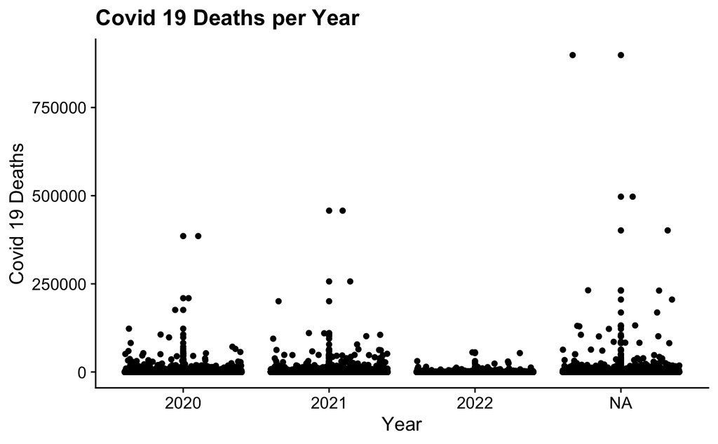

```r
Covid_19$Year<-as.factor(Covid_19$Year)
ggplot(Covid_19) +
  geom_jitter() +
  aes(x= Year, y= COVID.19.Deaths) +
    ggtitle("Covid 19 Deaths per Year") +
  xlab("Year") +
  ylab("Covid 19 Deaths") +
  geom_point() +
  theme_cowplot()
```

###We actually should get rid of the .5 notation if possible ot makes it look like the data isnt reported yearly. I tried to do this by making it a factor (only thing dif above) and this was the result. This is because all the “by total” groups = NAs, which we could just say in a sentence to ignore, but also I think by doing it like this we are accidentally graphing the month Values too… (BT comment) we might want to check that warning too

Here we can visualize if there is a difference in COVID-19 Deaths per month

```
Warning: Removed 20551 rows containing missing values (geom_point).
Warning: Removed 20551 rows containing missing values (geom_point).
```

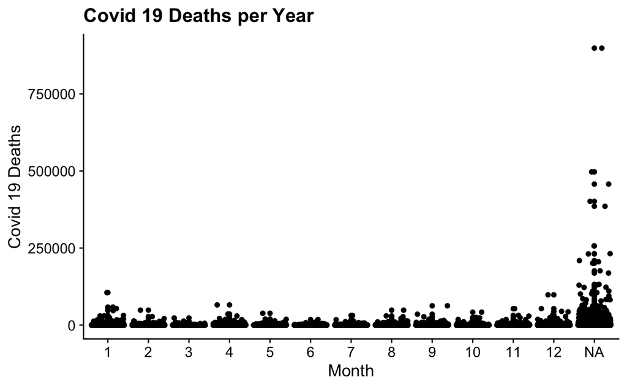

```r
ggplot(Covid_19) +
  geom_jitter() +
  aes(x= factor(Month), y= COVID.19.Deaths) +
    ggtitle("Covid 19 Deaths per Year") +
  xlab("Month") +
  ylab("Covid 19 Deaths") +
  geom_point()+
  theme_cowplot()
```

###Also we have a problem here. I tired to make it a factor and the NAs are also present because they are also for the total deaths. Beyond this, grouping it only by month but not accounting for year means that january 2020, 2021, and 2022 are all grouped under january…(BT comment) ###May need to explain factor() here

2. Plotting Data of COVID-19 Deaths from Pennsylvania (Total)

To narrow analysis, we can further look at the number of COVID-19 deaths per year and month in Pennsylvania. The state of Pennsylvania was chosen for epidemiological relevance. Furthermore, refining the dataset to a single state is beneficial for improved data visualization. The graphs above yielded general distributions of the dataframe, but limited information can be collected from them.

Data collection from Pennsylvania can be filtered from the “Covid_19” dataframe. This can be completed using the highly useful “filter” command. The structure of the filter command is as follows: new dataframe name<-filter(old dataframe name, column==/!=/>=/<= “Info from column”)

Filtering can be accomplished by specifying what one would like to take/remove from the original dataframe. One can use the following to: ==: Specify data that is equivalent to (think keep data) !=: Specify data that is not equal to (think remove data) <=: Specify data less than desired numeric data (use greater than sign for reverse process) &: Multiple filter commands; make a string of commands

Listed above are simply introductory commands that are used in conjunction with the filter command. Keep in mind, however, there are additional commands like is.na(), between(), and near() that can be used for advanced filtration. For the purpose of this project, we will mainly focus on the introductory commands.

This general theme of grouped data, as mentioned earlier in the project, is something to beware of. Be cautious when analyzing data and filtering data for statistical analysis.

This dataframe can be further refined using the filter function to explore COVID-19 deaths by Age, Group, and Year. Lets also make a graph.

A small problem arises with this analysis. The adolescent observations collected data at a different age intervals that are not consistent with the way the adult age intervals collected. Thus, one is forced to look at age range 0-17 for children, followed by a consistent 10 year interval range for adults.

This is OKAY, but should be noted with analysis. There was simply inconsistency with data collection that is beyond our control.

The filter command can be used to removed grouped data (i.e Age.Group!=“All Ages”) and can be used to remove undesired age ranges. Furthermore, the “Group==”By Total” should be applied to use inclusive grouped data that is comprised of all time data collected from 2020 to 2022 across our desired age ranges.

SECOND, in this same group of code, we can plot a graph for data visualization. The following steps take place which extend upon the steps used in part 1 of this data visualization section: 1. Create a graph name and graph using the ggplot package a. This graph will be titled “PennTotal”. PennTotal can be defined by (<-) ggplot() b. The structure of a basic plot is as possible ggplot(Dataframe, aes(x=column, y= column)) -Unless specified, R will choose the best fit plot with the given data (it might not be the desired plot you want) -aes= axis. Define the x and y axis of your plot by the independent and dependent variable. c. Specify the plot you wish ggplot to create. Lets create a point plot with a line. The structure of this command is as follows: geom_point(aes(colour=factor(binary variable))) -Geom_point creates a line graph. You can leave it here or add a binary variable -Binary variables can be distinguished by the function colour =factor(BV). Lets add sex into our graph/model -All data points can be added via the jitter command. Add position= “jitter” -The size and transparency of these data points can be defined using the commands alpha= and size= d. Specify a line of best fit with standard deviation. Use command geom_smoooth. The structure of this command is as follows: geom_smooth(formula = y ~ x,method=‘lm’,aes(group = factor(BV), colour = factor(BV))) -The formula is specified as y~x as a linear line is desired -Method=’lm” to specify a linear model -Group and colour should equal factor of the binary variable e. Clean the graph up by changing: -Change legend position by using theme function of ggplot: theme(legend.position = “right, left, top, bottom”) -Change title of plot via function: ggtitle(“Title”) -Change name of x/y axis and legend title via function: labs(x= “X Title”, y= “Y Title”, color= “Legend Title”) -Change aesthetics of x axis categories via function: theme(axis.text.x = element_text(angle = 1-180, vjust = numeric, hjust=numeric)) f. Apply theme_cowplot() which provides a classical plot appearance with two axis lines and no background grid. g. Plot using function plot(name of designated plot)

This is general outline of a plot can can be modified. Elements can be added or removed based on desired aesthetic appearance. ggplot packaged also plots more than line plots. A master list can be found at this link:

http://r-statistics.co/Top50-Ggplot2-Visualizations-MasterList-R-Code.html

### Do you think it would be a good idea to increase the size of these jitter points? I changed it from .05 to 1 and it looks a little more visible when I was messing with it (BT Comment)

One additional line of code, however, should be included to change the x axis numeric categories (which represent the numberic month) to a character (month name). This can be accomplished using the already loaded package “Stat2Data”. The command structure is as follows: scale_x_continuous(breaks = seq_along(month.name), labels = month.name). This line changes the month observation of “2” to display as February on the X axis.

(Line taken from https://stackoverflow.com/questions/69411847/changing-month-from-number-to-full-month-name-in-r)

###Need month to be numeric going into this… just a note cause it took me like 30 min to figure that out because I had converted it to a factor for code at line ~316 at first

Specify the geom_ of the plots by inserting geom_boxplot or geom_density into the code. Finally, theme_cowplot() allows users to plot the graphs in specified frames using the function: plot_grid(name, name, …, ncol=#).

###im confused what u mean for section 1 in the text above this chunk. Could we maybe add lines #s that go with the graph you are refering to

3. West Coast vs East Coast COVID-19 Death Exploration

Looking at differences in COVID-19 deaths between the East and West coast creates a problem in our original dataset. We have no segregation between these two variables. Thus, we must do so ourselves, and this can be completed via the creation of a new column in our original “Covid_19” dataframe.

The creation of a new data frame with an additional column that segretates the East and West coast states can be accomplished using the mutate command. A new column can be created that creates binary values of “TRUE” or “FALSE” where, for example, “TURE” is equivalent to states on the West coast and “FALSE” is equivalent to states on the East coast.

One can use the dpylr package to mutate their dataframe. This package is already preloaded into our RMD. Dplyr uses the operators %>% to pipeline commands. This is a close equivalent to using +.

The structure of the mutate command is as follows: dataframe%>% mutate(Added column=Column manipulated %in% c(specification of desired data)) This, almost filtered data, should be replaced into dataframe (new or old)-> dataframe.

Note <- and -> are the same function, but placement at the begging or end of code specify usage.

**Check to make sure new column as been added by opening up “Covid_19” from the environment.

One additional line of code can be included. We can specify the labels of the legend and the color of the represented binary factor. This can be accomplished via the command:scale_colour_manual(labels=c(“Title”, “Title”), values= c(“color”, “color”))

Colors can be represented numerous ways in R. However, they can be conveniently picked by utilizing this provided respurce from Columbia University.

http://www.stat.columbia.edu/~tzheng/files/Rcolor.pdf

This cheat sheet was created by Dr. Ying Wei.

STATISTICAL ANALYSIS:

#### Project Details

This project will require you to develop a tutorial to teach Bucknell students how to use R for graphing and data analysis.

## Target Audience

Discuss with your group the target audience for the tutorial. Examples could be one of the new core Biology classes, another 300-level course (not 364), or a research group.

## Grading

Each student will be expected to complete the following tasks to earn 85% of the points available for this assignment (21/25).

- Identify and obtain suitable dataset
- Use a Github repository and version control to collaborate on the project
- Spend 4-6 hours preparing, coding, and testing tutorial
  - Data exploration
  - Data visualization
  - Hypothesis testing
- Present tutorial in class
- Provide public archive suitable for sharing to students/faculty

Tutorials from previous classes can be viewed at our public github site: https://github.com/Bucknell-Biol364

Each group should use an *Acknowledgements* section to document the participation of each member and the collaboration within and between groups.

Additional credit will be awarded for providing assistance to other groups and for the development of a tutorial that goes beyond the minimal expectations listed above.